# FlexBayesMed: An R Package for Modelling Skewed and Heavy-Tailed Errors in Bayesian Mediation

Zongyu Li

# Installation

Install the stable CRAN release (once it is published):

```r
# Install from CRAN (when released)
# install.packages("FlexBayesMed")
```

Or, fetch the latest development version from GitHub:

```r
# Or grab the development version
# remotes::install_github("Zongyu-Li/FlexBayesMed/FlexBayesMed")
```

We note that **FlexBayesMed** relies on three packages:

| Package | Purpose |
| --- | --- |
| **rstan** | HMC/NUTS sampling for model fitting |
| **bridgesampling** | Marginal likelihoods and Bayes factors |
| **Rmpfr** | Arbitrary-precision arithmetic |

After installing the package, load it with the following command.

```r
library(FlexBayesMed)
```

# A Simple Linear Regression Model

First, let us consider the following linear regression specification:

$$Y_i = 1 + 2X_i + \sigma\varepsilon_i,\qquad i = 1, 2, \dots, 200.$$

We generate the covariates $X_i$ independently from the standard normal distribution, $\mathcal{N}(0,1)$.  
The error terms $\varepsilon_i$ are drawn independently from a centred two-piece Student $t$ distribution with skewness parameter $\gamma = 1.5$ and tail parameter $\nu = 5$. This choice produces a right-skewed, heavy-tailed error distribution; see Section 2 in Li, Steel, and Zhang (2025) for details.

Before fitting the model, we visualise this error distribution. The function `dctpt()` evaluates the probability density function of the centred two-piece Student $t$ distribution for a given sample, $\gamma$, and $\nu$.  
In the figure below, the error density is shown as a red solid line, while the standard normal density is added as a black dashed line for comparison.

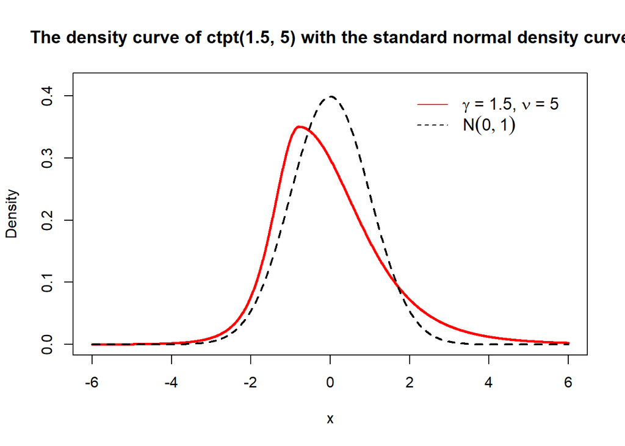

```r
# Plot the density curve on [-6, 6]
xseq <- seq(-6, 6, length.out = 2001)

plot(NA, xlim = range(xseq), ylim = c(0, 0.42), xlab = "x", ylab = "Density",
     main = "The density curve of ctpt(1.5, 5) with the standard normal density curve")

lines(xseq, dctpt(xseq,gamma=1.5,nu=5), col = "red", lwd = 2.5, lty=1)
lines(xseq, dnorm(xseq), col="black",lwd=2,lty=2)
legend("topright", inset = 0.04, cex   = 1.14,
       legend = c(expression(paste(gamma, " = 1.5, ", nu, " = 5")), expression(N(0,1))),
       col = c("red", "black"),
       lty = c(1,2),
       lwd = 1,
       bty = "n")
```

Because the error distribution is already centred at zero, no further location adjustment is required if we want to perform a mean regression.

Its theoretical mode and variance can be obtained with the functions `mode_ctpt()` and `var_ctpt()`, respectively.

```r
mode_ctpt(1.5, 5)
```

```
## [1] -0.7908473
```

```r
var_ctpt(1.5, 5)
```

```
## [1] 2.198635
```

The Fisher moment coefficient of skewness can be computed with the function `skewness_ctpt()`.

```r
skewness_ctpt(gamma=1.5, nu=5)
```

```
## [1] 1.516366
```

The cumulative distribution function of the centred two-piece Student $t$ distribution is provided by `pctpt()`.  
By definition, the probability mass to the left of the mode is $1/(1+\gamma^{2})$. We verify this numerically below.

```r
pctpt(q=mode_ctpt(1.5,5), gamma=1.5, nu=5)
```

```
## [1] 0.3076923
```

```r
1/(1+(1.5)^2)
```

```
## [1] 0.3076923
```

Quantiles of the centred two-piece Student $t$ distribution for any specified probability can be obtained with the `qctpt()` function.

```r
qctpt(p=0.5, gamma=1.5, nu=5)
```

```
## [1] -0.2265891
```

```r
# This should return the mode
qctpt(p=0.3076923, gamma=1.5, nu=5)
```

```
## [1] -0.7908473
```

Next, we generate random samples from the centred two-piece Student $t$ distribution with `rctpt()`.  
We then plot a histogram of the simulated values and overlay the theoretical density curve for comparison.

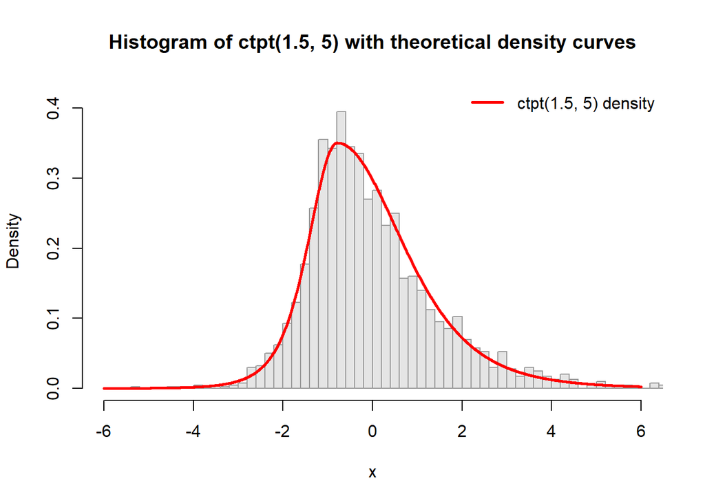

```r
set.seed(2025)
e <- rctpt(N=2000, gamma=1.5, nu=5)          # simulated samples

xseq <- seq(-6, 6, length.out = 2001)

hist(e,
     probability = TRUE,
     breaks       = 60,
     xlim         = range(xseq),
     ylim         = c(0, 0.42),
     col          = "grey90",
     border       = "grey60",
     xlab         = "x",
     ylab         = "Density",
     main = "Histogram of ctpt(1.5, 5) with theoretical density curves")

lines(xseq, dctpt(xseq, gamma = 1.5, nu = 5), col = "red",  lwd = 2.5)

legend("topright",
       legend = "ctpt(1.5, 5) density",
       lwd    = 2.5,
       col    = "red",
       lty    = 1,
       bty    = "n")
```

We now fit the linear regression model introduced above with `flex_mr()`. Arrange the predictors in a matrix `X`—there is no need to include an intercept column, as the function adds one automatically. Store the response variable in a numeric vector `y`, and pass both `X` and `y` to `flex_mr()`.

```r
set.seed(123)

# Create the independent variable and store it into a matrix
x <- rnorm(200)
X <- matrix(x, ncol = 1)

# Create the error terms ~ ctpt(1.5, 5)
e <- rctpt(N=200, gamma=1.5, nu=5)

# Create the dependent variable and store it into a vector
y <- 1 + 2*x + e
```

Now we call `flex_mr()` to fit the model. The function is a thin wrapper around **Stan** (Carpenter *et al.*, 2017), so it accepts the usual Stan sampling arguments. In this demo we run a single chain with 30 000 iterations, discarding the first 10 000 as warm-up.

To capture both skewness and heavy tails in the residuals, set `model = "full"`, which specifies the centred two-piece Student $t$ distribution for the errors. The prior hyper-parameters for $\gamma$ and $\nu$ are fully adjustable—the defaults follow Li, Steel, and Zhang (2025) (See Section 5).

For a complete list of options, consult `?flex_mr`.

```r
reg_m <- flex_mr(X=X, Y=y, model="full", iter=30000, warmup=10000, chains = 1, seed = 123, verbose = FALSE)
```

In our single-predictor example, `beta[1]` is the regression coefficient (its true value is 2). With three predictors, for example, the summary would instead list `beta[1]`, `beta[2]`, and `beta[3]`, one for each covariate.

```r
reg_m
```

```
## Inference for Stan model: anon_model.
## 1 chains, each with iter=30000; warmup=10000; thin=1;
## post-warmup draws per chain=20000, total post-warmup draws=20000.
##
##              mean se_mean   sd    2.5%     25%     50%     75%   97.5% n_eff
## intercept    0.84    0.00 0.11    0.64    0.77    0.84    0.91    1.06 15635
## beta[1]      2.00    0.00 0.10    1.81    1.93    2.00    2.06    2.18 17342
## sigma        1.04    0.00 0.10    0.85    0.97    1.03    1.10    1.24 13640
## gamma        1.57    0.00 0.18    1.26    1.45    1.56    1.68    1.96 14634
## nu           7.14    0.10 8.63    3.09    4.56    5.83    7.81   17.09  7881
## lp__      -353.08    0.02 1.63 -357.14 -353.92 -352.75 -351.88 -350.92  7906
##           Rhat
## intercept    1
## beta[1]      1
## sigma        1
## gamma        1
## nu           1
## lp__         1
##
## Samples were drawn using NUTS(diag_e) at Tue Aug  5 00:03:12 2025.
## For each parameter, n_eff is a crude measure of effective sample size,
## and Rhat is the potential scale reduction factor on split chains (at
## convergence, Rhat=1).
```

For guidance on extracting posterior samples and other operations with a Stan fit object, consult the Stan Reference Manual.

`flex_mr()` can also fit models with alternative error distributions:

```r
reg_m_Student <- flex_mr(X=X, Y=y, model="nu-only", iter=30000, warmup=10000, chains = 1, seed = 123, verbose = FALSE)
```

Again, we can obtain the posterior summaries:

```r
reg_m_Student
```

```
## Inference for Stan model: anon_model.
## 1 chains, each with iter=30000; warmup=10000; thin=1;
## post-warmup draws per chain=20000, total post-warmup draws=20000.
##
##              mean se_mean   sd    2.5%     25%     50%     75%   97.5% n_eff
## intercept    0.67    0.00 0.10    0.48    0.60    0.66    0.73    0.86 16925
## beta[1]      1.98    0.00 0.10    1.78    1.91    1.98    2.05    2.19 18394
## sigma        1.13    0.00 0.10    0.94    1.06    1.13    1.20    1.34 14230
## nu           4.88    0.02 1.81    2.64    3.68    4.49    5.62    9.52 12955
## lp__      -359.79    0.02 1.45 -363.46 -360.51 -359.45 -358.73 -357.99  8659
##           Rhat
## intercept    1
## beta[1]      1
## sigma        1
## nu           1
## lp__         1
##
## Samples were drawn using NUTS(diag_e) at Tue Aug  5 00:04:00 2025.
## For each parameter, n_eff is a crude measure of effective sample size,
## and Rhat is the potential scale reduction factor on split chains (at
## convergence, Rhat=1).
```

In practice, the true error distribution is unknown, so we often compare alternative models to identify the best fit. Within a Bayesian framework, Bayes factors provide a formal criterion for model comparison.

Here we use the **bridgesampling** package to compute the Bayes factor between `reg_m` and `reg_m_Student`.  
The calculation requires only a few lines of code. For detailed guidance, see the *bridgesampling* (Gronau, Singmann, & Wagenmakers, 2020).

```r
library(bridgesampling)

bridge_reg_m <- bridge_sampler(reg_m)
```

```
## Iteration: 1
## Iteration: 2
## Iteration: 3
## Iteration: 4
## Iteration: 5
```

```r
bridge_reg_m_Student <- bridge_sampler(reg_m_Student)
```

```
## Iteration: 1
## Iteration: 2
## Iteration: 3
## Iteration: 4
## Iteration: 5
```

```r
bf <- as.numeric(bf(bridge_reg_m, bridge_reg_m_Student))[1]
log(bf)
```

```
## [1] 5.97407
```

# A Basic Mediation Model

We now consider the mediation model
$$\begin{align}
M &= \beta_0^{(M)} + \alpha X + \sigma^{(M)}\varepsilon^{(M)},\\
Y &= \beta_0^{(Y)} + \tau X + \beta M +
\sigma^{(Y)}\varepsilon^{(Y)}.
\end{align}$$

Our aim is to estimate the indirect effect $\alpha\beta$ and test the null hypothesis $\alpha\beta = 0$.

For illustration we generate data with $\alpha = \beta = 0.7$, $\tau = 0.2$, $\beta_0^{(M)} = \beta_0^{(Y)} = 0$, and $\sigma^{(M)} = \sigma^{(Y)} = 1$. The error terms follow centred two-piece Student-$t$ distributions: $\varepsilon^{(M)} \sim \text{ctpt}(2, 3)$ (right-skewed) and $\varepsilon^{(Y)} \sim \text{ctpt}(0.33, 10)$ (left-skewed), each with distinct tail heaviness.

We begin by creating the synthetic dataset. As before, we draw $X$ from the standard normal distribution and set the sample size to $n = 200$.

```r
set.seed(321)
x <- rnorm(200) # vector
e_m <- rctpt(200, 2, 3)
e_y <- rctpt(200, 0.33, 10)
m <- 0.7*x + e_m # vector
y <- 0.2*x + 0.7*m + e_y # vector
```

To fit the mediation model and compute the Bayes factor for the indirect effect, a single call to `flex_med` is sufficient. Setting `model = "full"` fits centred two-piece Student-$t$ errors in both regression equations.  
Alternatively, specify `model = "gamma-only"`, `"nu-only"`, or `"normal"` to assume skew-normal, Student-$t$, or normal errors, respectively. Unlike `flex_mr()`, here `x`, `m` and `y` are all vectors.

The argument `q00` sets the prior conditional probability  
$\Pr(\alpha = 0,\; \beta = 0 \mid \alpha\beta = 0)$,  
while `q01` sets  
$\Pr(\alpha = 0,\; \beta = 1 \mid \alpha\beta = 0)$;  
see Liu, Zhang, and Wang (2023) for details.

```r
med_full <- flex_med(X=x, M=m, Y=y, model="full", q00=1/3, q01=1/3, iter=30000, warmup=10000, chains = 1, seed = 123, verbose = FALSE)
```

Running `flex_med()` may take a few minutes because it fits four separate models.  
The function returns a list containing six elements:

- **X2M_with_alpha** — Stan fit for
  $$M \;=\; \beta_0^{(M)} + \alpha X + \sigma^{(M)}\varepsilon^{(M)}.$$
- **X2M_without_alpha** — Stan fit for
  $$M \;=\; \beta_0^{(M)} + \sigma^{(M)}\varepsilon^{(M)}.$$
- **XM2Y_with_beta** — Stan fit for
  $$Y \;=\; \beta_0^{(Y)} + \tau X + \beta M +
  \sigma^{(Y)}\varepsilon^{(Y)}.$$
- **XM2Y_without_beta** — Stan fit for
  $$Y \;=\; \beta_0^{(Y)} + \tau X + \sigma^{(Y)}\varepsilon^{(Y)}.$$
- **samples_med** — posterior draws of the mediation effect $\alpha\beta$.
- **bf_med** — Bayes factor for the mediation effect.

You can summarise **samples_med** by computing its mean and the 2.5 % and 97.5 % quantiles to obtain a 95 % credible interval.

```r
# Posterior mean
mean(med_full$samples_med)
```

```
## [1] 0.4129882
```

```r
# Posterior mode (based on kernel density estimation)
d <- density(med_full$samples_med, adjust = 1)  # adjust = bandwidth factor (1 ≈ Silverman)
d$x[ which.max(d$y) ]
```

```
## [1] 0.4023447
```

```r
# Credible intervel
med_sorted <- sort(med_full$samples_med)
l <- length(med_sorted)

c(med_sorted[floor(l*0.025)], med_sorted[floor(l*0.975)])
```

```
## [1] 0.2696397 0.5763443
```

We can also plot the kernel density estimate of the mediation effect.

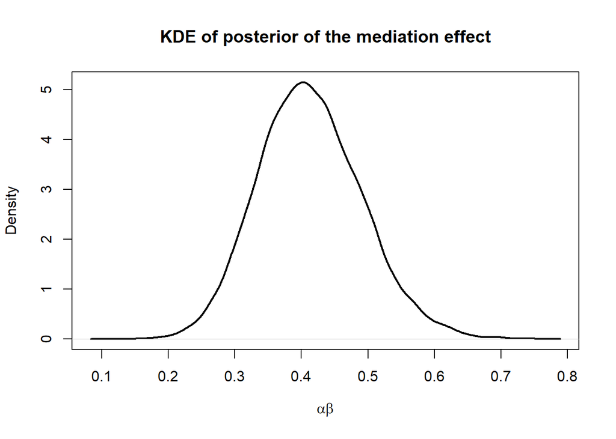

```r
# pick the column you want (e.g. "beta1")
x  <- med_full$samples_med

dens <- density(x, adjust = 1)
plot(dens,
     main  = "KDE of posterior of the mediation effect",
     xlab  = expression(paste(alpha,beta)),
     ylab  = "Density",
     lwd   = 2)
```

The final element, **bf_med**, contains the Bayes factor for the mediation effect.  
In this run, $\text{BF} \approx 9.16 \times 10^{6}$, providing overwhelming evidence that $\alpha\beta \neq 0$—exactly as expected from our simulation design.

```r
# Bayes factor
med_full$bf_med
```

```
## [1] 9163163
```

```r
# Bayes factor in log_10 scale
log(med_full$bf_med)
```

```
## [1] 16.0307
```

# More Features: Coming Soon

Currently, `flex_med()` supports only the basic mediation model described above. To accommodate more complex designs—such as moderated mediation—you can fit each constituent regression separately with `flex_mr()`, then apply bridge sampling to compute the Bayes factor for the mediation effect, as suggested in Li, Steel, and Zhang (2025).

# Reference

Carpenter, B., Gelman, A., Hoffman, M. D., Lee, D., Goodrich, B., Betancourt, M., Brubaker, M., Guo, J., Li, P., & Riddell, A. (2017). Stan: A probabilistic programming language. *Journal of Statistical Software, 76*, 1–32.

Gronau, Q. F., Singmann, H., & Wagenmakers, E. J. (2020). bridgesampling: An R package for estimating normalizing constants. *Journal of Statistical Software, 92*, 1–29.

Li, Z., Steel, M. F., & Zhang, Z. (2025+). Flexible Bayesian mediation with skew-heavy-tailed errors. *Unpublished Manuscript*.

Liu, X., Zhang, Z., & Wang, L. (2023). Bayesian hypothesis testing of mediation: Methods and the impact of prior odds specifications. *Behavior Research Methods, 55*(3), 1108–1120.